# Rectangular Data

This is **Tutorial 2.2** from the ESL course taught at the Faculty of Informatics and Information Technologies, Slovak University of Technology in Bratislava.

The course loosely follows the book *An* *Introduction to Statistical Learning with Applications in R*[^1], while also drawing inspiration from Hadley Wickham’s *Advanced R*[^2]. You may notice small insights borrowed from these two excellent books here and there because they set a remarkably high standard for beginners, and they’re very hard to surpass.

| Version | Last Edit | Changes |
| --- | --- | --- |
| 2026.1 | 12-2-2026 | Minor text changes. |

This tutorial is part of your pre‑study preparation. Make sure you’re confident with the material by the end of week 2. The ESL labs and hands‑on exercises use R and the tidyverse throughout, so these skills are essential for working through the course effectively.

### Motivation

Rectangular data are a fundamental concept in data science and statistics, referring to a two-dimensional array of values that are organized into rows and columns. This format is highly efficient for handling large datasets and is commonly used in programming languages like R and Python, particularly in their arrays and matrices.

In these structures, each row typically represents a different observation or *record*, while each column represents a different variable or feature. This organization allows for easy manipulation and analysis of the data, enabling tasks such as sorting, filtering, and applying statistical models. Rectangular data is also essential for multivariate analysis, where multiple variables are analyzed simultaneously to understand patterns and relationships within the data.

There are two basic forms in which rectangular data come in. In **long data**, the number of rows usually exceeds the number of columns and long tables have historically been used for statistical analysis. The **wide data**, by contrast, are the product of modern technologies that can simultaneously measure millions of variables for a single individual. It is more of a jargon that *attributes/variables* are referred to as *features* in wide data.

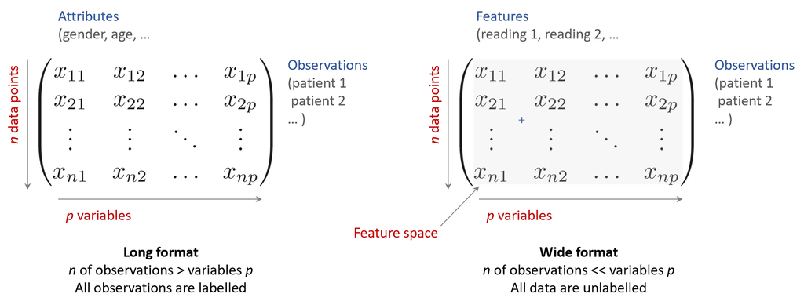

Both Python and R use data frames to handle rectangular data. However, simpler data formats might be more suitable for specific tasks:

- The simplest rectangular data type is an array, which is created by folding an atomic vector into multiple dimensions.
- A matrix, on the other hand, is built from multiple vectors that are bound together. Each row or column of a matrix comes from an independent vector, making matrices useful for storing results from repetitive computations.

### Arrays

Arrays are data structures that extend the capabilities of vectors by enabling more complex data storage and manipulation across multiple dimensions. Arrays remain prevalent in R programming due to their versatility and the powerful array-related functions provided by the language, facilitating a wide range of mathematical and statistical operations.

At their core, arrays are atomic vectors folded into two or more dimensions. An unidimensional array, however, remains an atomic vector.

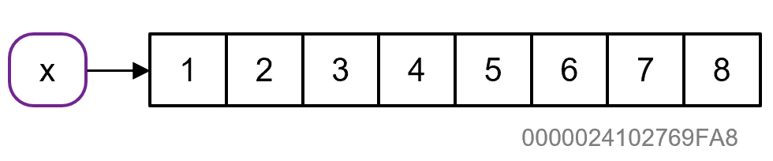

**Task 1:** Create an atomic vector `x` by concatenating integers 1 to 8. Use the following code, or come with your own solution.

```r
x <- 1:8 ; x
```

```
## [1] 1 2 3 4 5 6 7 8
```

Think about `x`. Has `x` any attributes? Use the `attributes()` to find out. Has `x` any rows and columns? Use `rownames()` and `colnames()` to check that out either. Explain why `NULL` is returned when `dim()` is applied to `x`.

**Task 2:** You can use the `dim()` function to fold `x` to an array with 2 rows and 4 columns. Study a R code below. Are arrays created by folding atomic vectors column- or row-wise?

```r
dim(x) <- c(2,4) ; x
```

```
##      [,1] [,2] [,3] [,4]
## [1,]    1    3    5    7
## [2,]    2    4    6    8
```

**Task 3:** Use the `dimnames()` function to name rows and columns.

```r
dimnames(x) <- list(c("Alpha", "Beta"),
                    c("Gamma", "Delta", "Epsilon","Zeta")) ; x
```

```
##       Gamma Delta Epsilon Zeta
## Alpha     1     3       5    7
## Beta      2     4       6    8
```

**Task 4:** The original array has two rows and four columns. If you don’t like this arrangement you can reshape `x` by providing new values to `dim(x)`. This process is called **casting**.

```r
dim(x) <- c(4,2) ; x
```

```
##      [,1] [,2]
## [1,]    1    5
## [2,]    2    6
## [3,]    3    7
## [4,]    4    8
```

The complementary process is **melting**. Melting effectively strips `x` from dimensions and returns `x` into the original one-dimensional state. Notice that dimensions of `x` can be changed dynamically without the need to melt `x` each time.

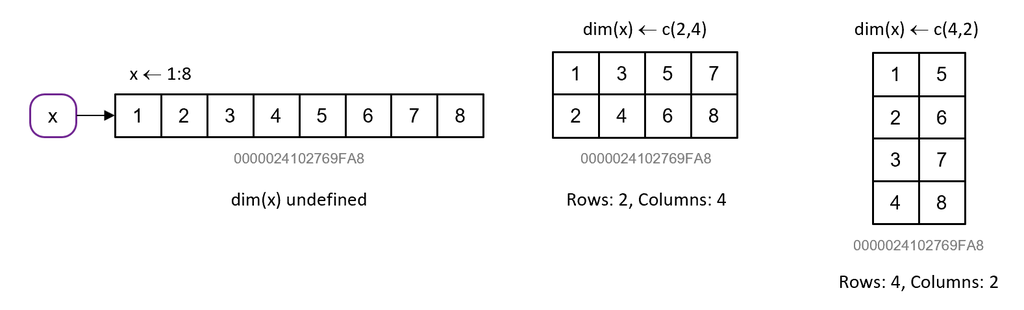

Note that row and column names are removed during the melting process. Therefore, it’s a good idea to store this information separately if you plan to use it later.

### Matrices

A matrix is a collection of elements of the same data type arranged into a fixed number of rows and columns. To create a matrix from `x`, use the `matrix()` constructor.

```r
matrix(x, nrow = 4)
```

[output not shown]

### Matrix Building by Row Binding

Often, accumulating data involves binding atomic vectors together. The only requirement is that the vectors must be of the same length and type. You can observe this behavior by filling an empty array `m` with randomly generated numbers from a normal distribution. Don’t worry too much about the loop syntax; this is just to demonstrate the historical purpose of matrices.

```r
set.seed(123)

# Build an empty matrix with 3 columns and no rows.
m <- matrix(nrow = 0, ncol = 3, byrow = TRUE)

# Fill an empty matrix with randomly generated triplets.
for (i in 1:3) m <- rbind(m, rnorm(n = 3, mean = i, sd = 0.5))

# Name rows and columns.
colnames(m) <- c("Alpha", "Beta", "Gamma")
rownames(m) <- c("Alpha", "Beta", "Gamma") ; m
```

```
##           Alpha      Beta    Gamma
## Alpha 0.7197622 0.8849113 1.779354
## Beta  2.0352542 2.0646439 2.857532
## Gamma 3.2304581 2.3674694 2.656574
```

Today, matrices are often replaced by data frames. This is because matrices are strictly two-dimensional and can only contain one type of data, which is limiting when dealing with complex datasets that have different types of data. Data frames, on the other hand, are more flexible, allowing different types of data to be stored in different columns, much like a spreadsheet.

In the R code example above, the code is executed in three iterations. In each step, `rbind()` attaches a new atomic vector to the growing matrix. The natural behavior of `rbind()` is row-binding. If you want to construct the matrix by column-binding instead of row-binding, use `cbind()`.

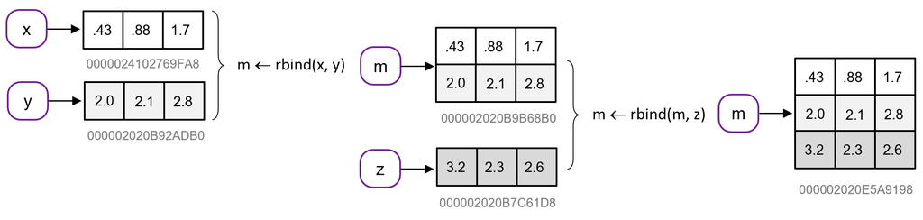

Now you know how to build matrices, let’s explore them more.

**Task 5:** Create three vectors `x`, `y`, and `z`, each containing three integers or doubles. `rbind()` `x`, `y` together, and then add `z`. Name the resulting object `m`, as for matrix.

**Task 6:** Call `typeof()`and `class()` functions on `m`. Use that information to explain how `m` is implemented *under the hood*.

**Task 7:** Explain Why `m`’s class is considered as an instance of array? Why is `m`’s type still considered integer?

**Task 8:** Reset dimensions of `m` by setting `dim()` value to `NULL`. What type of `m` do you get?

**Task 9:** Recast `m` to its original dimensions but this time as array. If you are not familiar with R constructor syntax for arrays, this information is available to you by typing `help("array")`.

### Arrays vs. Matrices

Arrays and matrices are vector applications for storing computation results that are similar in some respects, whilst different in other. Let’s summarize these differences.

| Arrays | Matrices |
| --- | --- |
| Arrays can contain greater than, or equal to 1 dimensions. | Matrices contains 2 dimensions in a table like structure. |
| Array is a homogeneous data structure. | Matrix is also a homogeneous data structure. |
| It is a singular vector arranged into the specified dimensions. | It comprises of multiple equal length vectors stacked together in a table. |
| `array()` function can be used to create arrays by specifying the third dimension to be 1. | `matrix()` function however can be used to create at most 2-dimensional array. |
| Arrays are superset of matrices. | Matrices are a subset, or special case of array where dimensions attribute is equal to two. |
| Limited set of collection-based operations. | Wide range of collection operations possible. |
| Mostly, intended for storage of measurements. | Mostly, matrices are intended for data transformation. |

The next table summarizes built-in functions that work with matrices and arrays.

| **Operation** | **Vector** | **Matrix** | **Array** |
| --- | --- | --- | --- |
| **Get names** | `names()` | `rownames()`;`colnames()` | `dimnames()` |
| **Get length** | `length()` | `nrow()`;`ncol()` | `dim()` |
| **Append** | `c()` | `rbind()`;`cbind()` | `abind()`[^3] |
| **Transpose** | - | `t()` | `aperm()` |

### Subsetting Operations

Subsetting of arrays follows the same principles as subsetting of atomic vectors with `[`:

- **Integer subsetting**: uses element indices, or
- **Logical subsetting** checks the validity of an expression for each element and keeps elements that are evaluated TRUE.

### Integer Subsetting

Let’s revisit matrix `m` from **Task 5**:

```r
m[c(1,3), 1:2]
```

```
##           Alpha      Beta
## Alpha 0.7197622 0.8849113
## Gamma 3.2304581 2.3674694
```

```r
m[1,]
```

```
##     Alpha      Beta     Gamma
## 0.7197622 0.8849113 1.7793542
```

The standard behavior of the `[` operator on `m` is to keep elements for which indices are provided. For example, `m[1,]` will subset `m` to row 1 while retaining all columns. Since arrays and matrices can have multiple dimensions, there are rules that help generalize integer and logical subsetting:

- The first position after `[` applies to rows, the second to columns, and so on.
- Multiple indices are provided as sequences of numbers, e.g., `1:3`, `c(1, 3, 5)`.
- Leaving an empty slot will keep all elements of that dimension in the output, e.g., `m[1,]`.

### Predicate and Logical Subsetting

R’s support for vectorized operations allows you to subset `m` using expressions like `m < 2` or `!is.na(x)`. The predicate returns a Boolean vector of the same length as `m`, indicating the positions of the elements to be retained. For example:

```r
m[c(TRUE, TRUE, FALSE), 1:2]
```

```
##           Alpha      Beta
## Alpha 0.7197622 0.8849113
## Beta  2.0352542 2.0646439
```

```r
m[m<2] # Subset rows in which all values are less that 2.
```

```
## [1] 0.7197622 0.8849113 1.7793542
```

**Task 10:** Explain why the following code won’t work: `m[m<2, ]`, `m[m<2, m<2]`, `m[] m<2`, `m[!is.na(),]`. Try to find the way (at least conceptually) to make it work.

### Footnotes

[^1]: James, Gareth, Daniela Witten, Trevor Hastie, and Robert Tibshirani. 2021. *An Introduction to Statistical Learning: With Applications in R*. 2nd ed. New York: Springer.
[^2]: Wickham, Hadley. 2019. *Advanced R*. 2nd ed. Boca Raton, FL: CRC Press.
[^3]: `abind()` is R package written by Tony Plate and Richard Heiberger, which generalizes `cbind()` and `rbind()`. Works with vectors, matrices and higher-dimensional arrays. https://cran.r-project.org/web/packages/abind/index.html